# 6.0 Cluster Analysis

## Overview

- Cluster analysis attempts to discover groups, or clusters, of observations that are homogenous in some way and separated from other clusters
  - Putting observations into distinguishable groups that are dissimilar to each other
  - Objects in the group should be similar or close together

## Hierarchical Clustering

- This produces a hierarchy of clusters (duh), where observations are split into clusters at different “levels” until each cluster is a single object
  - I have no idea how to better explain this, just look at the dendograms and it makes more sense
- Uses a distance matrix
  - Suggested to standardize the Euclidean distances if the variable units are different
  - All original data is used, so there is no error of dimension reduction like MDS
- Methods for measuring between-group distances
  - Single linkage
    - Choose the smallest distance between two groups
  - Complete linkage
    - Choose the maximum distance between two groups
  - Average linkage
    - Measure the average distance between all pairs

### Plotting Basic H-Clusters

#### Single Linkage Clustering

- To set up the example, we need to create a distance matrix
  - We’ll assume we have this matrix in advance, but we need to tell R that by changing the class from matrix to distance
- Use `as.dist()` to change the class from matrix to distance
- Use `hclust()`to perform the hierarchical cluster
  - First arg: distance matrix
  - Second arg: linkage method
1. Insert data, check the class of our new matrix

```r
d <- matrix(c(0, 1, 2, 8,
              1, 0, 7, 9,
              2, 7, 0, 6,
              8, 9, 6, 0), ncol = 4, byrow = T)
d
```

```
     [,1] [,2] [,3] [,4]
[1,]    0    1    2    8
[2,]    1    0    7    9
[3,]    2    7    0    6
[4,]    8    9    6    0
```

```r
class(d)
```

```
[1] "matrix" "array"
```

2. Change the class from matrix to distance

```r
d = as.dist(d)
class(d)
```

```
[1] "dist"
```

3. Create the hierarchical cluster with single linkage and plot

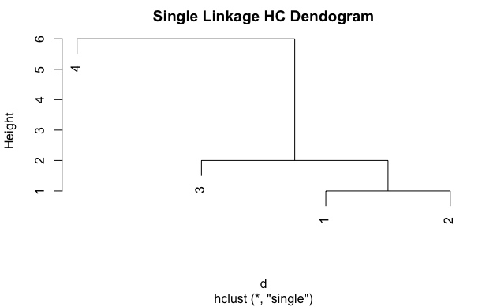

```r
hc <- hclust(d, "single")
plot(hc, main = "Single Linkage HC Dendogram")
```

#### Complete Linkage Clustering

- Similar to the process above, we just swap out the linkage argument in `hclust()`

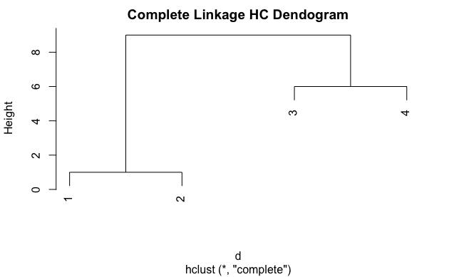

```r
hc <- hclust(d, "complete")
plot(hc, main = "Complete Linkage HC Dendogram")
```

- Query the heights from our hierarchical cluster analysis
- This responds to the dendogram above:
  - 1 & 2 are clustered at a hieght of 1
  - 3 & 4 are clustered at 6
  - All values are clustered at a height of 9

```r
hc$height
```

```
[1] 1 6 9
```

#### Average Linkage Clustering

```r
hc <- hclust(d, "average")
plot(hc, main = "Average Linkage HC Dendogram")
```

[output not shown]

### Basic Hierchical Clustering Example

Perform H-Clustering on Crime Data

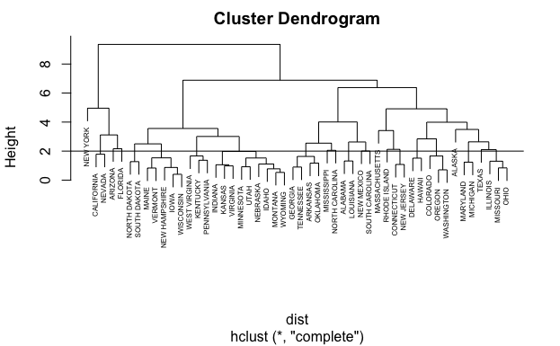

```r
crime <- read.csv("./Data Sets/crime.csv", row.names = "STATE")
crime.s <- scale(crime)

# create distance matrix
dist <- dist(crime.s)

# perform h-clustering analysis with complete linkage
hc1 <- hclust(dist, "complete")

# plot the dendogram
plot(hc1, cex = 0.5) # dendrogram

# plot an
abline(h=2) # This line is useful to determine clusters. If h=8, we divide th e data into two clusters.
```

### How Many Clusters?

- It can be difficult to determine how many clusters we should examine
- The more clusters we analyze, the more computing power and time we use
- There are diminishing returns to analyzing more clusters
  - We will use a scree plot to decide on the height cutoff
    - This will be the number of clusters we examine
  - Looking for the “elbow” of this plot helps identify efficient cluster cutoffs

#### Create Scree Plot

- In the last example we stored the h-cluster analysis in “hc1”
- Use `names(hc1)` to list the information available for us to query
  - To create the scree plot, we query for the reverse `rev()` of the heights in the h-cluster analysis

```r
# list the information stored in the h-cluster analysis
names(hc1)
```

```
[1] "merge"       "height"      "order"       "labels"      "method"
[6] "call"        "dist.method"
```

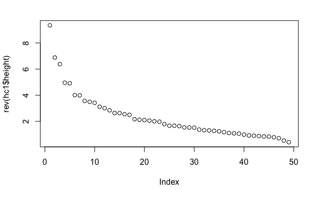

```r
# plot the reverse heights
plot(rev(hc1$height))
```

#### Perform H-Cluster with Specific # of Clusters

```r
ct <- cutree(hc1, 4)
```

- If you print this, you will see the list of all states and which one of the 4 clusters they were assigned to
- To save some screen real estate, we’ll just summarize the number of states in each cluster
  - Use `table()`

```r
table(ct)
```

```
ct
 1  2  3  4
10 16  5 19
```

#### Find Contents of Each Group

- Use `subset()`
  - Pass in the rownames of the data set and the cluster number

```r
cluster1 = subset(rownames(crime), ct==1)
cluster1
```

```
 [1] "ALABAMA"        "ARKANSAS"       "GEORGIA"        "LOUISIANA"
 [5] "MISSISSIPPI"    "NEW MEXICO"     "NORTH CAROLINA" "OKLAHOMA"
 [9] "SOUTH CAROLINA" "TENNESSEE"
```

#### Interpreting Cluster Data

- Looking at the scaled values in the data (z-scores) can help identify relationships
  - Use `scale()` to obtain z-scores
  - Match the cluster data to their respective row names
  - Examine the column means of that matched index
- This can be repeated for all 4 clusters, here I just ran the first one
  - States in this cluster exhibit high scaled values for murder and assault
  - Our job is to try to interpret what qualitative groupings are implied by this cluster

```r
crime.s = scale(crime)

index1 = match(cluster1, rownames(crime))

colMeans(crime.s[index1, ])
```

```
    MURDER       RAPE    ROBBERY    ASSAULT   BURGLARY    LARCENY       AUTO
 1.0360071  0.2329076 -0.2438296  0.7039187 -0.1490187 -0.7846000 -0.6172153
```

### Comparing Linkage Methods

- This dataset uses the iris data set which gives measurements (in centimeters) of flower sepal dimensions for 3 types of iris
  - Don’t worry I also had to google it, the sepal is the little leafy part directly below the flower that protects it while it grows
  - The three species are Iris Setosa, Versicolor, and Virginia because you were dying to know
1. Check out the table
- Save the data minus the species column into mydata object
- Plot and color with the species from the original data to see the actual “clusters”

```r
head(iris)
```

|  | Sepal.Length | Sepal.Width | Petal.Length | Petal.Width | Species |
| --- | --- | --- | --- | --- | --- |
| 1 | 5.1 | 3.5 | 1.4 | 0.2 | setosa |
| 2 | 4.9 | 3.0 | 1.4 | 0.2 | setosa |
| 3 | 4.7 | 3.2 | 1.3 | 0.2 | setosa |
| 4 | 4.6 | 3.1 | 1.5 | 0.2 | setosa |
| 5 | 5.0 | 3.6 | 1.4 | 0.2 | setosa |
| 6 | 5.4 | 3.9 | 1.7 | 0.4 | setosa |

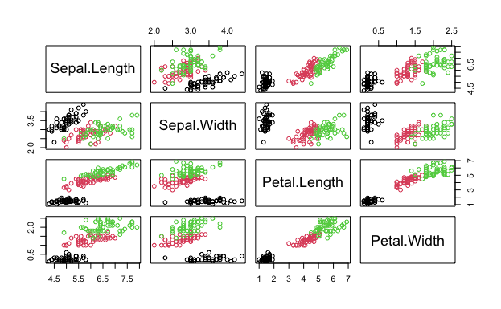

```r
mydata1= iris[,-5]
plot(mydata1, col = iris$Species)
```

2. Start our analysis by scaling the data and performing single linkage clustering

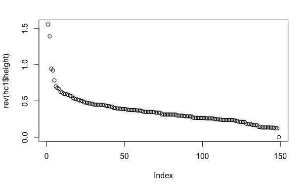

```r
# scale the data
mydata1.s = scale(mydata1)

# perform single link cluster
hc1 = hclust(dist(mydata1.s), "single")

# create the scree plot
plot(rev(hc1$height))
```

3. Based on the scree plot above and definitely not cheating with our knowledge that we have three actual clusters, we’ll attempt the analysis with 3 clusters
- To check the quality, create a contingency table for the H-clusters and true clusters (the species)
  - The flowers placed in each cluster by single linkage don’t appear as balanced as we’d expect

```r
ct1 = cutree(hc1, 3)

# summarize single linkage results
table(ct1)
```

```
ct1
  1   2   3
 49   1 100
```

```r
# create contingency table
table(ct1, iris$Species)
```

```
ct1 setosa versicolor virginica
  1     49          0         0
  2      1          0         0
  3      0         50        50
```

4. Try average linkage
- This actually looks like 4 clusters, but the professor tells us to cheat and use 3 since we know this the truth
  - Poor ethics if you ask me, now my notes are meaningless

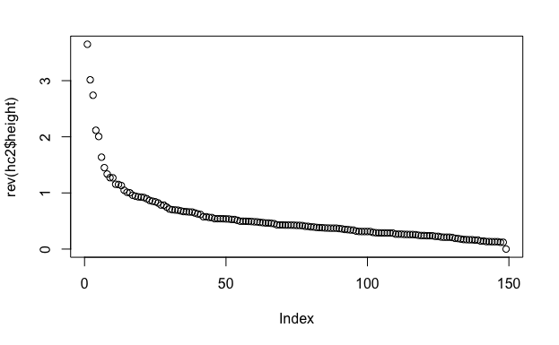

```r
hc2 = hclust(dist(mydata1.s), "average")

plot(rev(hc2$height))
```

5. Cut the average linkage at 3 clusters because we are liars and scoundrels
- The resulting contingency table with the original species still isn’t good
  - This is probably punishment for our crimes

```r
ct2 = cutree(hc2, 3)
table(ct2)
```

```
ct2
 1  2  3
50 97  3
```

```r
table(ct2, iris$Species)
```

```
ct2 setosa versicolor virginica
  1     50          0         0
  2      0         50        47
  3      0          0         3
```

6. Finally we’ll try the default of complete linkage
- This time a clear 3 clusters are visible

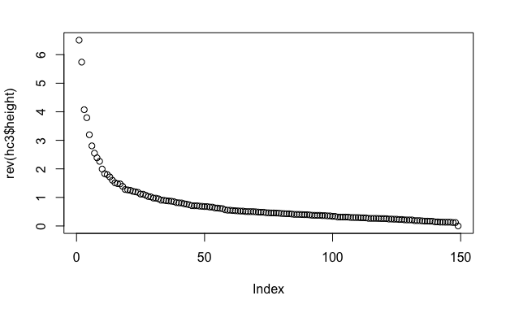

```r
hc3 = hclust(dist(mydata1.s), "complete")

plot(rev(hc3$height))
```

7. You know the drill, complete linkage contingency table
- Except this time our clusters look much more acurately distributed

```r
ct3 = cutree(hc3, 3)
table(ct3)
```

```
ct3
 1  2  3
49 24 77
```

```r
table(ct3, iris$Species)
```

```
ct3 setosa versicolor virginica
  1     49          0         0
  2      1         21         2
  3      0         29        48
```

8. Compare the cluster colorings of the “true” and complete linkage clusters

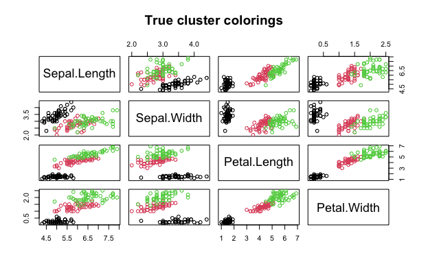

```r
plot(mydata1, col = iris$Species, main = "True cluster colorings" )
```

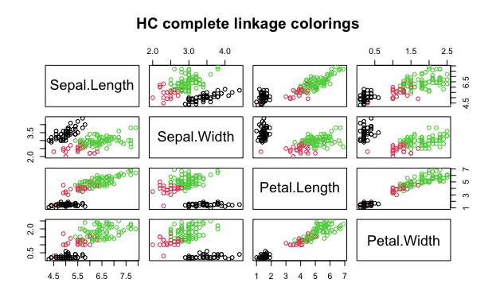

```r
plot(mydata1, col = ct3, main = "HC complete linkage colorings")
```

### Testing Clusters with Simulation Data

Under construction :)